(LSE - ST510 Foundations of Machine Learnig - WT2024)

# Deep Neural Networks

This notebook demonstrates the **design** of a Deep Convolutional Neural Networks (CNN) for a **digit classification** problem.

We add two specialised layers (**convolutional and pooling**) and subsequent optimisation techniques to the models, and assess our CNN models performance over the **MNIST** dataset.

## 0. Set up

```python
# importing necessary modules
import numpy as np
import pandas as pd
import matplotlib.pyplot as plt
import time
# deep learning modules
import tensorflow as tf
from tensorflow import keras
from keras.models import Sequential
from keras.layers import Dense, Flatten, MaxPooling2D, Conv2D, Dropout
# data preprocessing
from keras.utils import to_categorical
```

## 1. Data loading and preprocessing

In this example, we use the [MNIST](https://keras.io/api/datasets/mnist/) digits classification dataset available on Keras.

The **MNIST** (**Modified National Institute of Standards and Technology**) database is a large database of handwritten digits that is commonly used for training various image processing system. It contains 60,000 28x28 grayscale images of the 10 digits, along with a test set of 10,000 images. More info can be found at [here](https://en.wikipedia.org/wiki/MNIST_database).

```python
# load the dataset and split into training/testing features and labels
(x_train, y_train), (x_test, y_test) = keras.datasets.mnist.load_data()
# data normalization
x_train, x_test = x_train / 255.0, x_test / 255.0
```

```python
# checking data structure
print(x_train.shape)
print(x_test.shape)
```

```
(60000, 28, 28)
(10000, 28, 28)
```

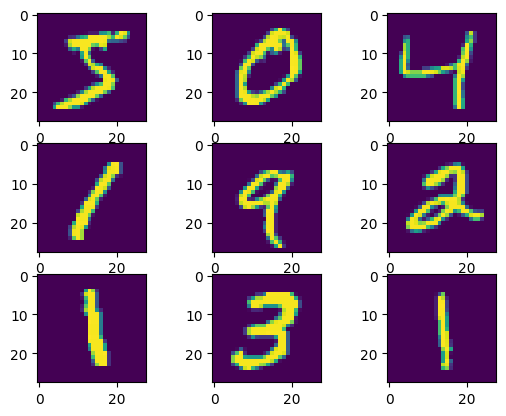

```python
# plot first few images
for i in range(9):
 # define subplot
 plt.subplot(330 + 1 + i)
 # plot raw pixel data
 plt.imshow(x_train[i]) # add cmap=plt.get_cmap('gray') for greyscale
# show the figure
plt.show()
```

### Label enconding

```python
# print first ten (integer valued) training labels
print('Integer-valued labels: ')
print(y_train[:10])
```

```
Integer-valued labels:
[5 0 4 1 9 2 1 3 1 4]
```

```python
# one-hot encode the labels
y_train = to_categorical(y_train, 10)
y_test = to_categorical(y_test, 10)

#print first ten (one hot) training labels
print('One-hot labels: ')
print(y_train[:10])
```

```
One-hot labels:
[[0. 0. 0. 0. 0. 1. 0. 0. 0. 0.]
 [1. 0. 0. 0. 0. 0. 0. 0. 0. 0.]
 [0. 0. 0. 0. 1. 0. 0. 0. 0. 0.]
 [0. 1. 0. 0. 0. 0. 0. 0. 0. 0.]
 [0. 0. 0. 0. 0. 0. 0. 0. 0. 1.]
 [0. 0. 1. 0. 0. 0. 0. 0. 0. 0.]
 [0. 1. 0. 0. 0. 0. 0. 0. 0. 0.]
 [0. 0. 0. 1. 0. 0. 0. 0. 0. 0.]
 [0. 1. 0. 0. 0. 0. 0. 0. 0. 0.]
 [0. 0. 0. 0. 1. 0. 0. 0. 0. 0.]]
```

## 2. Training hyperparameters

For simplicity, we will define some **hyperparameters for model definition and training** here.

```python
# epochs of training
n_epochs = 15
# batch size (default to 32)
# batch_size_t = 128
```

## 3. CNN models - comparative analysis

```python
# regularised model with kernel initialisation and L2 regularisation
model_l2 = Sequential()
model_l2.add(Flatten(input_shape=(28, 28))),
model_l2.add(Dense(128, activation='relu',
                   kernel_initializer=keras.initializers.HeNormal(),
                   kernel_regularizer=keras.regularizers.l2(0.0001)))
model_l2.add(Dense(10,   # the number of classes
                   activation='softmax',
                   kernel_initializer=keras.initializers.HeNormal(),
                   kernel_regularizer=keras.regularizers.l2(0.0001)))

# model summary
model_l2.summary()

# compile the model with a cross-entropy loss and specify the given optimizer
model_l2.compile(optimizer='Adam', loss=keras.losses.CategoricalCrossentropy(), metrics=['accuracy'])
```

```
Model: "sequential_7"
_________________________________________________________________
 Layer (type)                Output Shape              Param #
=================================================================
 flatten_7 (Flatten)         (None, 784)               0
```

```
 dense_10 (Dense)            (None, 128)               100480

 dense_11 (Dense)            (None, 10)                1290

=================================================================
Total params: 101,770
Trainable params: 101,770
Non-trainable params: 0
_________________________________________________________________
```

```python
history_l2 = model_l2.fit(x_train, y_train, epochs=n_epochs, batch_size=32, validation_split=0.2)
```

```python
# checkpoint the model at its final state
CHECKPOINT_PATH = '/drive/MyDrive/checkpoints'
model_l2.save_weights('{}/checkpoint_MNIST_model_l2'.format(CHECKPOINT_PATH))
```

```python
# # we can call back the model by downloading the saved checkpoint

# # first we need to re-instantiate the same model
# model_l2 = Sequential()
# model_l2.add(Flatten(input_shape=(28, 28))),
# model_l2.add(Dense(128, activation='relu', kernel_initializer=keras.initializers.HeNormal(), kernel_regularizer=keras.regularizers.l2(0.0001)))
# model_l2.add(Dense(10, activation='softmax', kernel_initializer=keras.initializers.HeNormal(), kernel_regularizer=keras.regularizers.l2(0.0001)))

# # and compile it
# model_l2.compile(optimizer='Adam', loss=keras.losses.CategoricalCrossentropy(), metrics=['accuracy'])

# # then we load the weights
# model_l2.load_weights('{}/checkpoint_MNIST_model_l2'.format(CHECKPOINT_PATH))
```

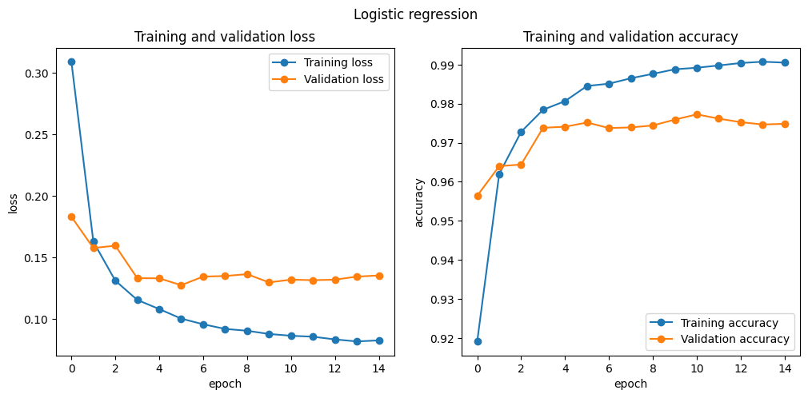

```python
# training and validation loss
f, (ax1, ax2) = plt.subplots(1, 2, figsize=(12, 5))
ax1.plot(history_l2.history['loss'],'-o', label='Training loss')
ax1.plot(history_l2.history['val_loss'],'-o', label='Validation loss')
ax1.set_title('Training and validation loss')
ax1.set_ylabel('loss')
ax1.set_xlabel('epoch')
ax1.legend(loc='upper right')
ax2.plot(history_l2.history['accuracy'],'-o', label='Training accuracy')
ax2.plot(history_l2.history['val_accuracy'],'-o', label='Validation accuracy')
ax2.set_title('Training and validation accuracy')
ax2.set_ylabel('accuracy')
ax2.set_xlabel('epoch')
ax2.legend(loc='lower right')
f.suptitle('Logistic regression')
```

```python
# evaluate test accuracy
score = model_l2.evaluate(x_test, y_test, verbose=0)
accuracy = 100 * score[1]
# print test accuracy
print('Test accuracy %.2f%%' % accuracy)
```

```
Test accuracy 97.72%
```

### Second model: baseline NN + Conv2D

In this second model, we introduce a **convolution layer** to summarise the input images into the most relevant features.

A **convolution** is the simple **application of a filter to an input that results in an activation**. Repeated application of the same filter to an input results in a **map of activations** called a **feature map**, indicating the locations and strength of a detected feature in an input, such as an image ([reference](https://machinelearningmastery.com/convolutional-layers-for-deep-learning-neural-networks/)).

```python
# second model
# YOUR CODE HERE
model2 = Sequential()
model2.add(Conv2D(32, (3, 3), input_shape=(28, 28, 1), padding='same', activation='relu'))
model2.add(Flatten())
model2.add(Dense(10, activation='softmax'))
model2.summary()
```

```
Model: "sequential_8"
_________________________________________________________________
 Layer (type)                Output Shape              Param #
=================================================================
 conv2d (Conv2D)             (None, 28, 28, 32)        320

 flatten_8 (Flatten)         (None, 25088)             0

 dense_12 (Dense)            (None, 10)                250890

=================================================================
Total params: 251,210
Trainable params: 251,210
Non-trainable params: 0
_________________________________________________________________
```

```python
# model training
# YOUR CODE HERE
model2.compile(optimizer='Adam', loss=keras.losses.CategoricalCrossentropy(), metrics=['accuracy'])
history2 = model2.fit(x_train, y_train, epochs=n_epochs, batch_size=32, validation_split=0.2)
```

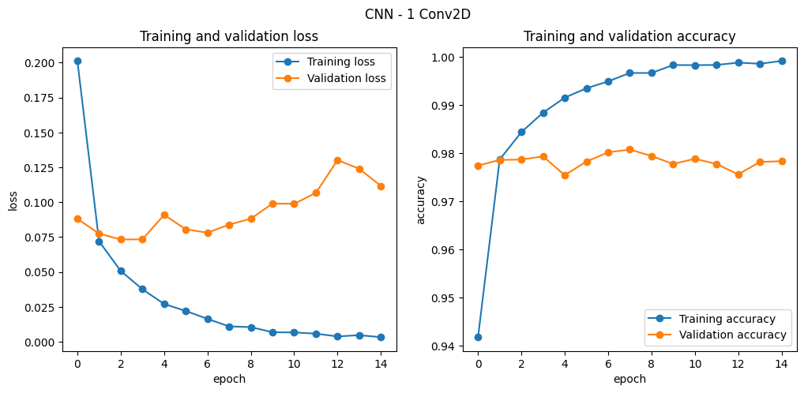

```python
# training and validation loss
f, (ax1, ax2) = plt.subplots(1, 2, figsize=(12, 5))
ax1.plot(history2.history['loss'],'-o', label='Training loss')
ax1.plot(history2.history['val_loss'],'-o', label='Validation loss')
ax1.set_title('Training and validation loss')
ax1.set_ylabel('loss')
ax1.set_xlabel('epoch')
ax1.legend(loc='upper right')
ax2.plot(history2.history['accuracy'],'-o', label='Training accuracy')
ax2.plot(history2.history['val_accuracy'],'-o', label='Validation accuracy')
ax2.set_title('Training and validation accuracy')
ax2.set_ylabel('accuracy')
ax2.set_xlabel('epoch')
ax2.legend(loc='lower right')
f.suptitle('CNN - 1 Conv2D')
```

```python
# evaluate test accuracy
score = model2.evaluate(x_test, y_test, verbose=0)
accuracy = 100*score[1]
# print test accuracy
print('Test accuracy %.2f%%' % accuracy)
```

```
Test accuracy 98.10%
```

### Third model: baseline NN + (Conv2D+MaxPooling) block

In this model, we add a **pooling layer** to **reduce the dimensions of the feature maps**. Pooling layers are used along with convolutional layers to reduce the number of parameters to learn and the amount of computation performed in the network. **The pooling layer summarises the features present in a region of the feature map generated by a convolution layer**.

```python
# third model
model3 = Sequential()
model3.add(Conv2D(32, (3, 3), input_shape=(28, 28, 1), padding='same', activation='relu'))
model3.add(MaxPooling2D())   # default size: (2, 2)
model3.add(Flatten())
model3.add(Dense(10, activation='softmax'))
model3.summary()
```

```
Model: "sequential_9"
_________________________________________________________________
 Layer (type)                Output Shape              Param #
=================================================================
 conv2d_1 (Conv2D)           (None, 28, 28, 32)        320

 max_pooling2d (MaxPooling2D  (None, 14, 14, 32)       0
 )

 flatten_9 (Flatten)         (None, 6272)              0

 dense_13 (Dense)            (None, 10)                62730

=================================================================
Total params: 63,050
Trainable params: 63,050
Non-trainable params: 0
_________________________________________________________________
```

```python
# compile and run
model3.compile(optimizer='Adam', loss=keras.losses.CategoricalCrossentropy(), metrics=['accuracy'])
history3 = model3.fit(x_train, y_train, epochs=n_epochs, batch_size=32, validation_split=0.2)
# YOUR CODE HERE
```

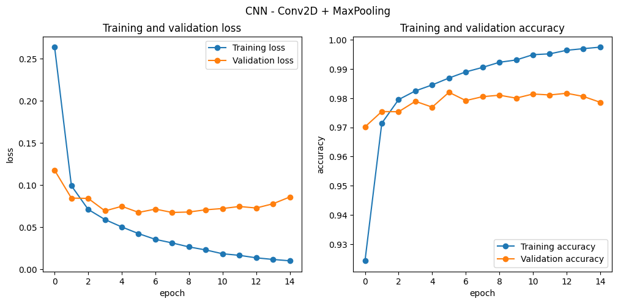

```python
# training and validation loss
f, (ax1, ax2) = plt.subplots(1, 2, figsize=(12, 5))
ax1.plot(history3.history['loss'],'-o', label='Training loss')
ax1.plot(history3.history['val_loss'],'-o', label='Validation loss')
ax1.set_title('Training and validation loss')
ax1.set_ylabel('loss')
ax1.set_xlabel('epoch')
ax1.legend(loc='upper right')
ax2.plot(history3.history['accuracy'],'-o', label='Training accuracy')
ax2.plot(history3.history['val_accuracy'],'-o', label='Validation accuracy')
ax2.set_title('Training and validation accuracy')
ax2.set_ylabel('accuracy')
ax2.set_xlabel('epoch')
ax2.legend(loc='lower right')
f.suptitle('CNN - Conv2D + MaxPooling')
```

```python
# evaluate test accuracy
score = model3.evaluate(x_test, y_test, verbose=0)
accuracy = 100*score[1]
# print test accuracy
print('Test accuracy %.2f%%' % accuracy)
```

```
Test accuracy 98.02%
```

### 4. baseline NN + double Conv2D + MaxPooling blocks

Once you have a model with **stable performance**, you can try to improve it by **adding redundant CNN blocks (`Conv2D + MaxPooling + Dropout`)** the same way that most pre-build CNN models do. This will give you a **deeper model** that presumably is able to generalise to other (more challenging) datasets *within the same domain of the training/testing images*. You can add **dropout** layers to the dense layers and convolutions.

**Note** that the redundant blocks **do not need to have the same structure - number of units and filter dimensions**. You can experiment with different configurations.

```python
# redundant CNN blocks
model4 = Sequential()
model4.add(Conv2D(16, (3, 3), input_shape=(28, 28, 1), padding='same', activation='relu'))
model4.add(MaxPooling2D())
model4.add(Conv2D(32, (3, 3), padding='same', activation='relu'))
model4.add(MaxPooling2D())
model4.add(Flatten())
model4.add(Dropout(.5))
model4.add(Dense(10, activation='softmax'))
model4.summary()
```

```
Model: "sequential_10"
_________________________________________________________________
 Layer (type)                Output Shape              Param #
=================================================================
 conv2d_2 (Conv2D)           (None, 28, 28, 16)        160

 max_pooling2d_1 (MaxPooling  (None, 14, 14, 16)       0
 2D)

 conv2d_3 (Conv2D)           (None, 14, 14, 32)        4640

 max_pooling2d_2 (MaxPooling  (None, 7, 7, 32)         0
 2D)

 flatten_10 (Flatten)        (None, 1568)              0

 dropout (Dropout)           (None, 1568)              0

 dense_14 (Dense)            (None, 10)                15690

=================================================================
Total params: 20,490
Trainable params: 20,490
Non-trainable params: 0
_________________________________________________________________
```

```python
model4.compile(optimizer='adam', loss='categorical_crossentropy', metrics=['acc'])
history4 = model4.fit(x_train, y_train, epochs=n_epochs, batch_size=32, validation_split=0.2)
```

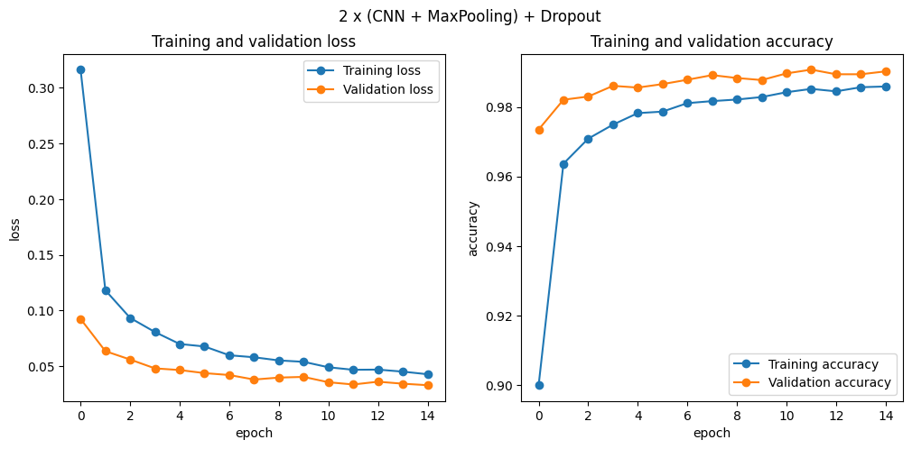

```python
# training and validation loss
f, (ax1, ax2) = plt.subplots(1, 2, figsize=(12, 5))
ax1.plot(history4.history['loss'],'-o', label='Training loss')
ax1.plot(history4.history['val_loss'],'-o', label='Validation loss')
ax1.set_title('Training and validation loss')
ax1.set_ylabel('loss')
ax1.set_xlabel('epoch')
ax1.legend(loc='upper right')
ax2.plot(history4.history['acc'],'-o', label='Training accuracy')
ax2.plot(history4.history['val_acc'],'-o', label='Validation accuracy')
ax2.set_title('Training and validation accuracy')
ax2.set_ylabel('accuracy')
ax2.set_xlabel('epoch')
ax2.legend(loc='lower right')
f.suptitle('2 x (CNN + MaxPooling) + Dropout')
```

```python
# evaluate test accuracy
score = model4.evaluate(x_test, y_test, verbose=0)
accuracy = 100 * score[1]
# print test accuracy
print('Test accuracy %.2f%%' % accuracy)
```

```
Test accuracy 99.13%
```

### 5. Same as 4, without dropout

```python
# redundant CNN blocks
model5 = Sequential()
model5.add(Conv2D(16, (3,3), input_shape=(28,28,1), padding='same', activation='relu'))
model5.add(MaxPooling2D())
model5.add(Conv2D(32, (3,3), padding='same', activation='relu'))
model5.add(MaxPooling2D())
model5.add(Flatten())
model5.add(Dense(10, activation='softmax'))
model5.summary()
```

```
Model: "sequential_11"
_________________________________________________________________
 Layer (type)                Output Shape              Param #
=================================================================
 conv2d_4 (Conv2D)           (None, 28, 28, 16)        160

 max_pooling2d_3 (MaxPooling  (None, 14, 14, 16)       0
 2D)

 conv2d_5 (Conv2D)           (None, 14, 14, 32)        4640

 max_pooling2d_4 (MaxPooling  (None, 7, 7, 32)         0
 2D)

 flatten_11 (Flatten)        (None, 1568)              0

 dense_15 (Dense)            (None, 10)                15690

=================================================================
Total params: 20,490
Trainable params: 20,490
Non-trainable params: 0
_________________________________________________________________
```

```python
model5.compile(optimizer='adam', loss='categorical_crossentropy', metrics=['acc'])
history5 = model5.fit(x_train, y_train, epochs=n_epochs, batch_size=32, validation_split=0.2)
```

[figure not shown]

```python
# training and validation loss
f, (ax1, ax2) = plt.subplots(1, 2, figsize=(12, 5))
ax1.plot(history5.history['loss'],'-o', label='Training loss')
ax1.plot(history5.history['val_loss'],'-o', label='Validation loss')
ax1.set_title('Training and validation loss')
ax1.set_ylabel('loss')
ax1.set_xlabel('epoch')
ax1.legend(loc='upper right')
ax2.plot(history5.history['acc'],'-o', label='Training accuracy')
ax2.plot(history5.history['val_acc'],'-o', label='Validation accuracy')
ax2.set_title('Training and validation accuracy')
ax2.set_ylabel('accuracy')
ax2.set_xlabel('epoch')
ax2.legend(loc='lower right')
f.suptitle('2 x (CNN + MaxPooling) + Dropout')
```

```python
# evaluate test accuracy
score = model5.evaluate(x_test, y_test, verbose=0)
accuracy = 100*score[1]
# print test accuracy
print('Test accuracy %.2f%%' % accuracy)
```

```
Test accuracy 98.93%
```

### Other improvements

You can try a combination of model architectural parameters and training parameters to keep improving your model.

**Model improvements:**

- kernel initializer and kernel regularizer
- MaxPooling2D pool_size
- Dropout
- Batch normalization

**Training hyperparameters:**

- batch size and number of epochs
- validation split
- callbacks, including [model checkpoint](https://keras.io/api/callbacks/model_checkpoint/)

## 4. Model prediction

We can **pick the best model** (in our case, **model4** - but for visualisation purposed we will use model5) and use it for prediction by passing a new data instance (in this example, we simply pick on `X_test` sample).

```python
from numpy import asarray
from numpy import argmax

# print options for float numbers
#np.set_printoptions(formatter={'float_kind':'{:.8f}'.format})

# make a prediction
image = x_test[102]
yhat = model5.predict(asarray([image]))
print('Predicted values: ', yhat)
print('\nPredicted: class = %d' % argmax(yhat))
print('True class: ', np.argmax(y_test[102]))
```

```
Predicted values:  [[6.4090058e-30 8.1439188e-29 1.3198875e-29 6.1854825e-14 1.7887340e-31
  1.0000000e+00 2.1651468e-29 3.6963649e-23 5.9470850e-16 3.5451289e-13]]

Predicted: class = 5
True class:  5
```

```python
predictions = model5.predict(x_test)
tf.math.confusion_matrix(np.argmax(y_test, axis=1), np.argmax(predictions, axis=1))
```

```
<tf.Tensor: shape=(10, 10), dtype=int32, numpy=
array([[ 969,    0,    1,    0,    0,    0,    6,    1,    3,    0],
       [   1, 1126,    1,    1,    1,    0,    3,    1,    1,    0],
       [   1,    1, 1024,    0,    1,    0,    1,    2,    2,    0],
       [   0,    0,    3,  999,    0,    5,    0,    1,    1,    1],
       [   0,    0,    0,    0,  976,    0,    1,    0,    2,    3],
       [   1,    0,    0,    5,    0,  880,    2,    1,    2,    1],
       [   2,    1,    1,    0,    1,    1,  950,    0,    2,    0],
       [   0,    3,   11,    1,    1,    0,    0, 1007,    1,    4],
       [   2,    0,    1,    0,    0,    1,    1,    0,  968,    1],
       [   0,    1,    1,    0,    6,    3,    1,    2,    1,  994]])>
```

# 5. Grad-CAM explainability method

This code is adapted from [this Keras tutorial](https://keras.io/examples/vision/grad_cam/).

```python
def plt_images(x_test, i_max, j_max):
  fig, axs = plt.subplots(i_max, j_max, figsize=plt.figaspect(0.5))
  for i in range(i_max):
    for j in range(j_max):
      ind = np.arange(i_max*j_max)[i*j_max+j]
      img = x_test[ind].reshape(1,28,28,1)
      axs[i, j].imshow(img[0,:,:,0], aspect='auto')
  return
```

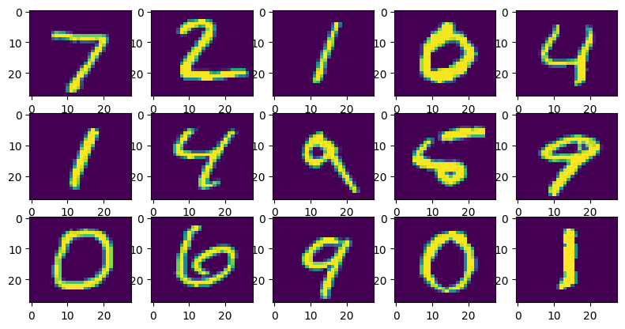

```python
nrow = 3
ncol = 5
plt_images(x_test, nrow, ncol)
```

```python
def make_gradcam_heatmap(img_array, model, last_conv_layer_name, pred_index=None):
    # First, we create a model that maps the input image to the activations
    # of the last conv layer as well as the output predictions
    grad_model = keras.models.Model(
        model.inputs, [model.get_layer(last_conv_layer_name).output, model.output]
    )

    # Then, we compute the gradient of the top predicted class for our input image
    # with respect to the activations of the last conv layer
    with tf.GradientTape() as tape:
        last_conv_layer_output, preds = grad_model(img_array)
        if pred_index is None:
            pred_index = tf.argmax(preds[0])
        class_channel = preds[:, pred_index]

    # This is the gradient of the output neuron (top predicted or chosen)
    # with regard to the output feature map of the last conv layer
    grads = tape.gradient(class_channel, last_conv_layer_output)

    # This is a vector where each entry is the mean intensity of the gradient
    # over a specific feature map channel
    pooled_grads = tf.reduce_mean(grads, axis=(0, 1, 2))

    # We multiply each channel in the feature map array
    # by "how important this channel is" with regard to the top predicted class
    # then sum all the channels to obtain the heatmap class activation
    last_conv_layer_output = last_conv_layer_output[0]
    heatmap = last_conv_layer_output @ pooled_grads[..., tf.newaxis]
    heatmap = tf.squeeze(heatmap)

    # For visualization purpose, we will also normalize the heatmap between 0 & 1
    heatmap = tf.maximum(heatmap, 0) / tf.math.reduce_max(heatmap)
    return heatmap.numpy()

def plot_gradcam_images(i_max, j_max, x_test, model, layer_name):
  fig, axs = plt.subplots(i_max, j_max, figsize=plt.figaspect(0.5))
  for i in range(i_max):
    for j in range(j_max):
      ind = np.arange(i_max*j_max)[i*j_max+j]
      heatmap = make_gradcam_heatmap(tf.expand_dims(x_test[ind], axis=0), model, layer_name)
      axs[i, j].matshow(heatmap, aspect='auto')
  plt.tight_layout()
  plt.show()
  return
```

```python
model5.summary()
```

```
Model: "sequential_11"
_________________________________________________________________
 Layer (type)                Output Shape              Param #
=================================================================
 conv2d_4 (Conv2D)           (None, 28, 28, 16)        160

 max_pooling2d_3 (MaxPooling  (None, 14, 14, 16)       0
 2D)

 conv2d_5 (Conv2D)           (None, 14, 14, 32)        4640

 max_pooling2d_4 (MaxPooling  (None, 7, 7, 32)         0
 2D)

 flatten_11 (Flatten)        (None, 1568)              0

 dense_15 (Dense)            (None, 10)                15690

=================================================================
Total params: 20,490
Trainable params: 20,490
Non-trainable params: 0
_________________________________________________________________
```

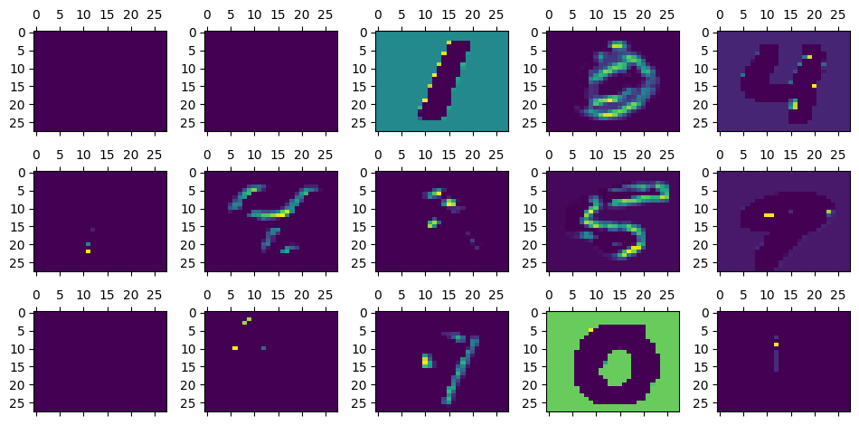

```python
plot_gradcam_images(nrow, ncol, x_test, model5, 'conv2d_4')
```

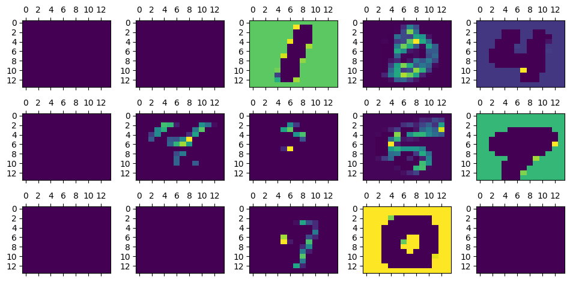

```python
plot_gradcam_images(nrow, ncol, x_test, model5, 'max_pooling2d_3')
```

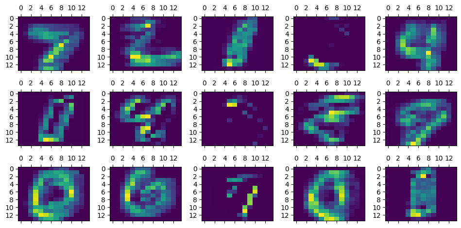

```python
plot_gradcam_images(nrow, ncol, x_test, model5, 'conv2d_5')
```

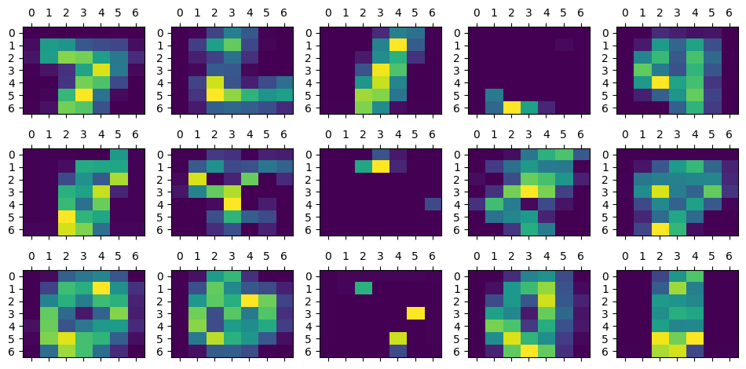

```python
plot_gradcam_images(nrow, ncol, x_test, model5, 'max_pooling2d_4')
```